# P.lagopus dbRDA

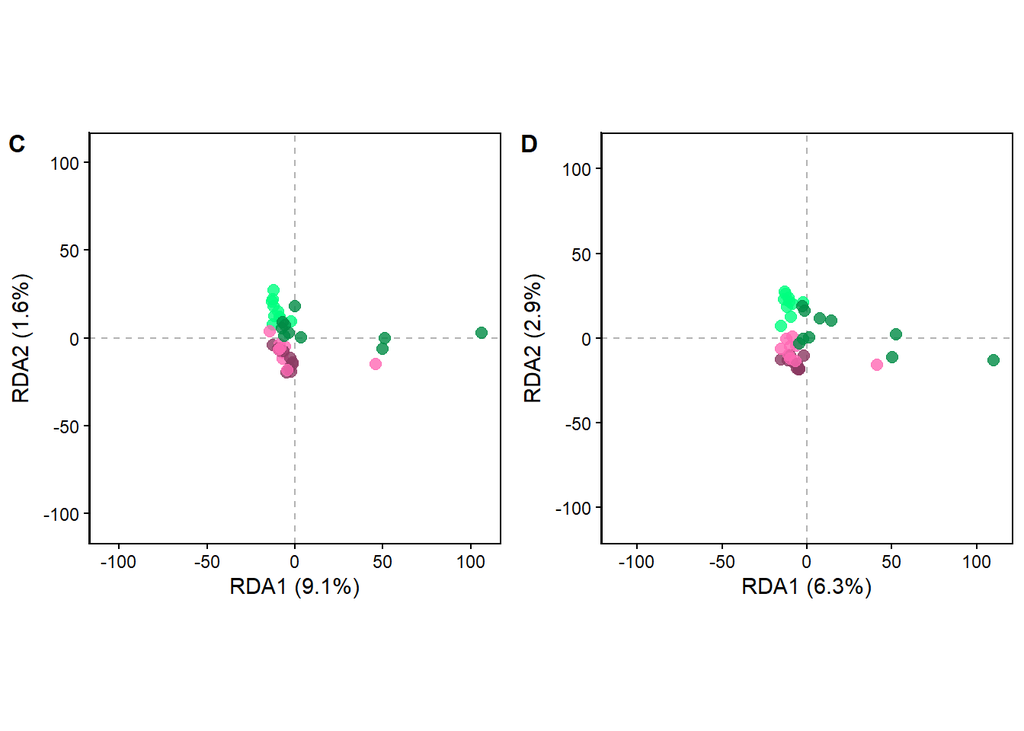

Fig. 2. Epigenetic differentiation plots using methylation data for cytosines in CpG (A), CHG (B), CHH (C), and in all contexts. Ordination plots of the distance-based redundancy analysis (dbRDA) carried out to test for epigenetic differences with maternal environment and real-time herbivory simulation as predictors (EpiDist ~ M * S). RDA1: first constrained ordination axis; RDA2: second constrained ordination axis. Samples are colored by group (i.e.: maternal environment x real-time herbivory simulation).

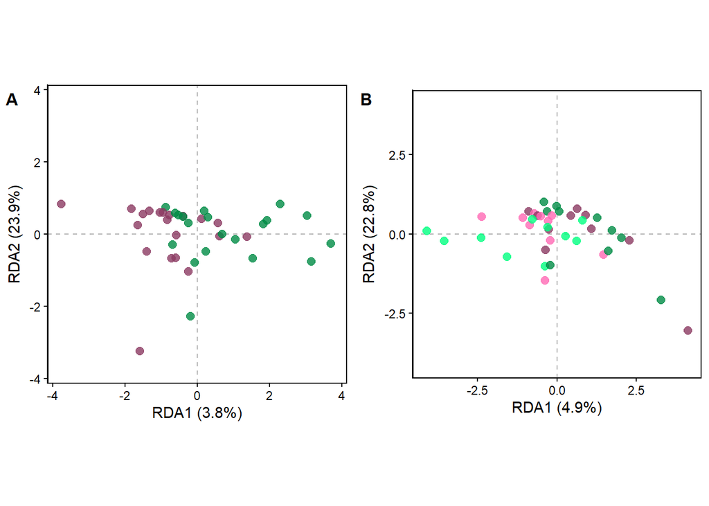

Fig. 3. Phenotypic differentiation plots. Ordination plots of the distance-based redundancy analysis (dbRDA) carried out to test for phenotypic differences with both maternal environment as predictor (A: PhenoDIST ~ M), and the interaction of maternal environment and real-time herbivory as predictor (B: PhenoDIST ~ M * S) (PhenoDIST ~ M * S). RDA1: first constrained ordination axis; RDA2: second constrained ordination axis. Samples are colored by group (i.e.: maternal environment x real-time herbivory simulation).

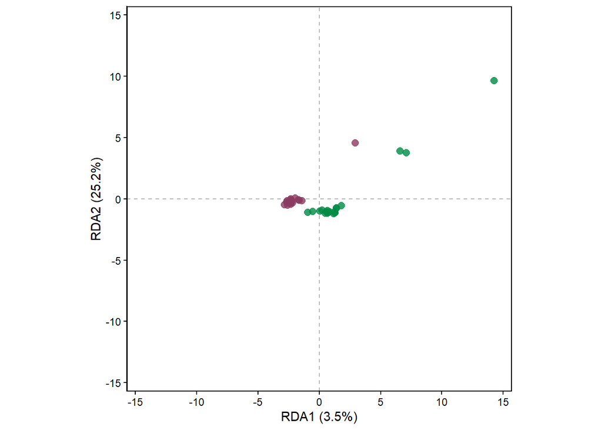

Fig. 4. Genetic differentiation plots. Ordination plots of the distance-based redundancy analysis (dbRDA) carried out to test for Genetic differences with maternal environment as predictor (GenDIST ~ M). RDA1: first constrained ordination axis; RDA2: second constrained ordination axis. Samples are colored by maternal environment.